# Homework 4

## Problem 2

### 2.2

Read the training data and test data:

```r
load("../HW03/zip.RData")
```

Apply the Naive Bayes classifier:

```r
library(e1071)
dat.nb <- naiveBayes(V1 ~ ., data=dat$train)
y.test.nb <- predict(dat.nb, newdata=dat$test)
```

Confusion matrix:

```r
table(y.test.nb, dat$test[,1])
```

```
y.test.nb   1   3   5
        1 255   0   1
        3   3 153  25
        5   6  13 134
```

Misclassification rate:

```r
mean(y.test.nb != dat$test[,1])
```

```
[1] 0.08135593
```

## Problem 3

### 3.1

5-fold cross validation:

```r
generate_indices <- function(n, k, seed=10) {
  set.seed(seed)
  ind <- rep(0, n)
  a <- split(sample(1:n), 1:k)
  for (j in 1:k) { ind[a[[j]]] <- j }
  ind
}
cv.5fold <- function(data, predictor, seed=10) {
  ind <- generate_indices(nrow(data), 5, seed)
  errors <- sapply(1:5, function(j) {
    set.seed(seed)
    y.hat <- predictor(data[ind != j,], data[ind == j,])
    mean(y.hat != data[ind == j,1])
  })
  mean(errors)
}
```

```r
library(class)
knn.predictor <- function(train, test, k) {
  knn(train[,-1], test[,-1], train[,1], k=k, prob=F)
}
```

Calculate training error, 5-fold CV error and test error for kNN classifier with different `k` values:

```r
train.errors <- rep(0, 15)
cv.errors <- rep(0, 15)
test.errors <- rep(0, 15)
for (k in 1:15) {
  predictor <- function(train, test) { knn.predictor(train, test, k) }
  cv.errors[k] <- cv.5fold(dat$train, predictor)
  set.seed(10)
  train.errors[k] <- mean(knn(dat$train[,-1], dat$train[,-1], dat$train[,1], k=k, prob=F) != dat$train[,1])
  test.errors[k] <- mean(knn(dat$train[,-1], dat$test[,-1], dat$train[,1], k=k, prob=F) != dat$test[,1])
  cat("k =", k, ", train error =", train.errors[k], ", cv error =", cv.errors[k], ", test error =", test.errors[k], "\n")
}
```

```
k = 1 , train error = 0 , cv error = 0.01306916 , test error = 0.03050847
k = 2 , train error = 0.006759802 , cv error = 0.0166748 , test error = 0.03898305
k = 3 , train error = 0.004055881 , cv error = 0.01081589 , test error = 0.03389831
k = 4 , train error = 0.005858495 , cv error = 0.009014093 , test error = 0.03559322
k = 5 , train error = 0.005858495 , cv error = 0.0130712 , test error = 0.03050847
k = 6 , train error = 0.005407841 , cv error = 0.01081793 , test error = 0.03220339
k = 7 , train error = 0.006309148 , cv error = 0.01217131 , test error = 0.03050847
k = 8 , train error = 0.005407841 , cv error = 0.01352165 , test error = 0.03728814
k = 9 , train error = 0.008111762 , cv error = 0.01307018 , test error = 0.03559322
k = 10 , train error = 0.009463722 , cv error = 0.01352368 , test error = 0.03389831
k = 11 , train error = 0.007661109 , cv error = 0.01352368 , test error = 0.03559322
k = 12 , train error = 0.008111762 , cv error = 0.01307221 , test error = 0.03559322
k = 13 , train error = 0.008111762 , cv error = 0.01487605 , test error = 0.04067797
k = 14 , train error = 0.008562416 , cv error = 0.01577797 , test error = 0.03728814
k = 15 , train error = 0.01036503 , cv error = 0.01758079 , test error = 0.0440678
```

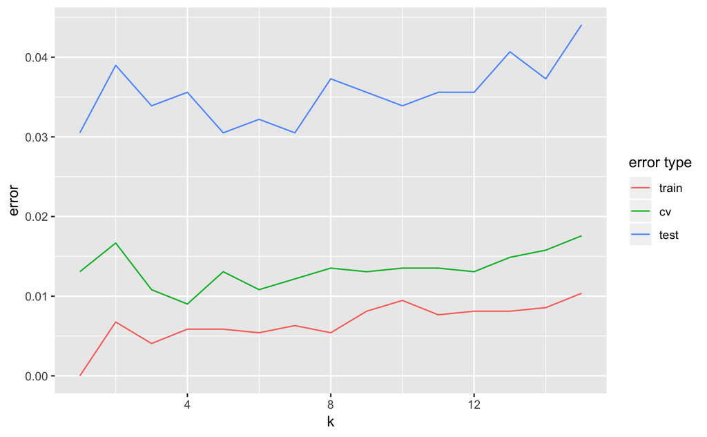

```r
library(ggplot2)
library(reshape2)
errors <- data.frame(k=1:15, train=train.errors, cv=cv.errors, test=test.errors)
errors <- melt(errors, id="k")
ggplot(errors) + geom_line(aes(k, value, color=variable)) + labs(y="error", color="error type")
```

Alternatively, use the `caret` package to train kNN classifier:

```r
library(caret)
set.seed(1234)
train.control <- trainControl(method="repeatedcv", number=5, repeats=1)
dat.knn <- train(V1 ~ ., data=dat$train, method="knn", trControl=train.control, tuneGrid=expand.grid(k=1:15))
dat.knn
```

```
k-Nearest Neighbors

2219 samples
 256 predictor
   3 classes: '1', '3', '5'

No pre-processing
Resampling: Cross-Validated (5 fold, repeated 1 times)
Summary of sample sizes: 1775, 1776, 1775, 1775, 1775
Resampling results across tuning parameters:

  k   Accuracy   Kappa
   1  0.9873803  0.9804011
   2  0.9824233  0.9726905
   3  0.9905385  0.9853073
   4  0.9869339  0.9797042
   5  0.9896356  0.9839013
   6  0.9860320  0.9783037
   7  0.9887337  0.9824974
   8  0.9873813  0.9803939
   9  0.9855775  0.9775770
  10  0.9851290  0.9768741
  11  0.9869308  0.9796814
  12  0.9846776  0.9761697
  13  0.9842281  0.9754620
  14  0.9846786  0.9761569
  15  0.9842271  0.9754594

Accuracy was used to select the optimal model using the largest value.
The final value used for the model was k = 3.
```

### 3.2

`k`=1 performs the best based on the training error:

```r
which(train.errors == min(train.errors))
```

```
[1] 1
```

`k`=1, 5 and 7 perform the best based on the test error:

```r
which(test.errors == min(test.errors))
```

```
[1] 1 5 7
```

`k`=4 performs the best based on the CV error:

```r
which(cv.errors == min(cv.errors))
```

```
[1] 4
```

### 3.3

Run CV ten times with different random seeds for `k`=4 (which yields the lowest CV error above):

```r
cv.errors2 <- rep(0, 10)
for (seed in 1:10) {
  set.seed(seed)
  predictor <- function(train, test) { knn.predictor(train, test, 4) }
  cv.errors2[seed] <- cv.5fold(dat$train, predictor, seed)
}
cv.errors2
```

```
 [1] 0.011265329 0.011714762 0.012622781 0.012164196 0.013069164 0.012617697 0.012615663 0.013520631
 [9] 0.012166229 0.009014093
```

The CV errors are different when using different random seeds.

### 3.4

The function to generate equal sample sizes for each fold was already implemented above in 3.1. Check with `n`=12 (12 samples) and `k`=5 (5 folds):

```r
for (seed in 1:5) {
  ind <- generate_indices(12, 5, seed)
  print(ind)
}
```

```
 [1] 5 5 4 1 2 3 1 2 4 2 1 3
 [1] 2 4 1 5 3 3 1 2 4 2 5 1
 [1] 2 3 1 3 5 2 5 1 2 1 4 4
 [1] 2 1 3 4 2 3 5 1 2 4 5 1
 [1] 5 2 1 2 1 4 3 2 1 3 5 4
```

## Problem 4

### 4.1

Number of support vectors for different values of the cost:

```r
nSV <- c()
costs <- 10^(-5:5)
for (cost in costs) {
  data.svm <- svm(V1 ~ ., data=dat$train, cost=cost, scale=F)
  nSV <- c(nSV, data.svm$tot.nSV)
}
nSV
```

```
 [1] 1929 1890 1873 1548  705  308  256  256  256  256  256
```

Plot the number of support vectors vs. C:

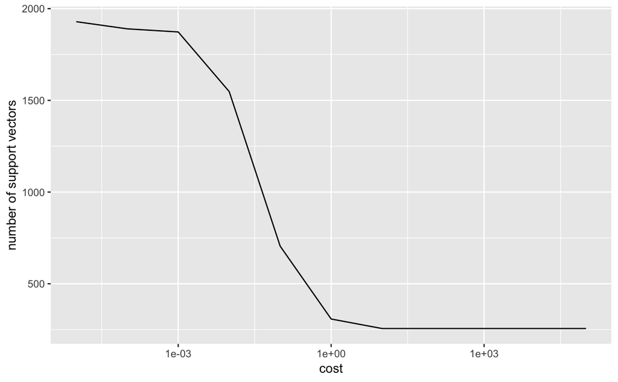

```r
ggplot(data=data.frame(costs,nSV), aes(costs, nSV)) +
  geom_line() + scale_x_log10() + labs(x="cost", y="number of support vectors")
```

### 4.2

Calculate 5-fold CV errors for different cost values:

```r
cv.errors <- c()
for (cost in costs) {
  predictor <- function(train, test) {
    data.svm <- svm(V1 ~ ., data=train, cost=cost, scale=F)
    predict(data.svm, test)
  }
  cv.error <- cv.5fold(dat$train, predictor, seed=10)
  cv.errors <- c(cv.errors, cv.error)
  cat("cost =", cost, ", cv error =", cv.error, "\n")
}
```

```
cost = 1e-05 , cv error = 0.547096
cost = 1e-04 , cv error = 0.547096
cost = 0.001 , cv error = 0.547096
cost = 0.01 , cv error = 0.2510148
cost = 0.1 , cv error = 0.02298721
cost = 1 , cv error = 0.01261668
cost = 10 , cv error = 0.007660708
cost = 100 , cv error = 0.007660708
cost = 1000 , cv error = 0.007660708
cost = 10000 , cv error = 0.007660708
cost = 1e+05 , cv error = 0.007660708
```

The following cost values have the lowest CV error:

```r
costs[which(cv.errors == min(cv.errors))]
```

```
[1] 1e+01 1e+02 1e+03 1e+04 1e+05
```

### 4.3

Here we use cost = 10:

```r
data.svm <- svm(V1 ~ ., data=dat$train, cost=10, scale=F)
y.test.svm <- predict(data.svm, dat$test)
mean(y.test.svm != dat$test[,1])
```

```
[1] 0.03389831
```

Confusion matrix for the test data:

```r
table(y.test.svm, dat$test[,1])
```

```
y.test.svm   1   3   5
         1 260   0   0
         3   2 154   4
         5   2  12 156
```

Function for plotting the digit data as an image:

```r
conv.image <- function(vec)
{
mat <- matrix(as.numeric(vec), nrow=16, ncol=16)
mat <- -mat[, 16 : 1]
par(mar=c(0, 0, 0, 0))
image(mat, col=gray(seq(0, 1, 0.01)), xaxt='n', yaxt='n')
}
```

One’s that are misclassified as three’s:

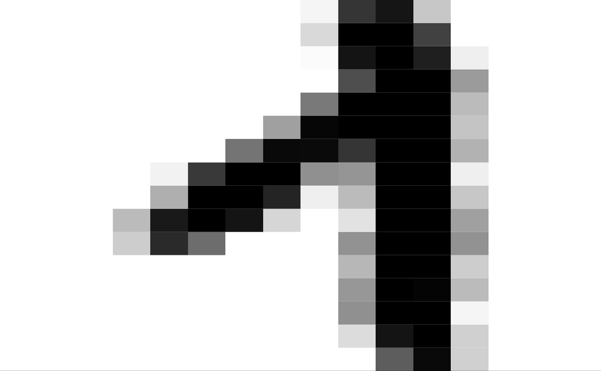

```r
one.as.three <- intersect(which(y.test.svm==3), which(dat$test[,1]==1))
conv.image(dat$test[one.as.three[1], -1])
for (i in 1:length(one.as.three)) {
  pdf(paste0('one.as.three', i, '.pdf'))
  conv.image(dat$test[one.as.three[i], -1])
  dev.off()
}
```

One’s that are misclassified as five’s:

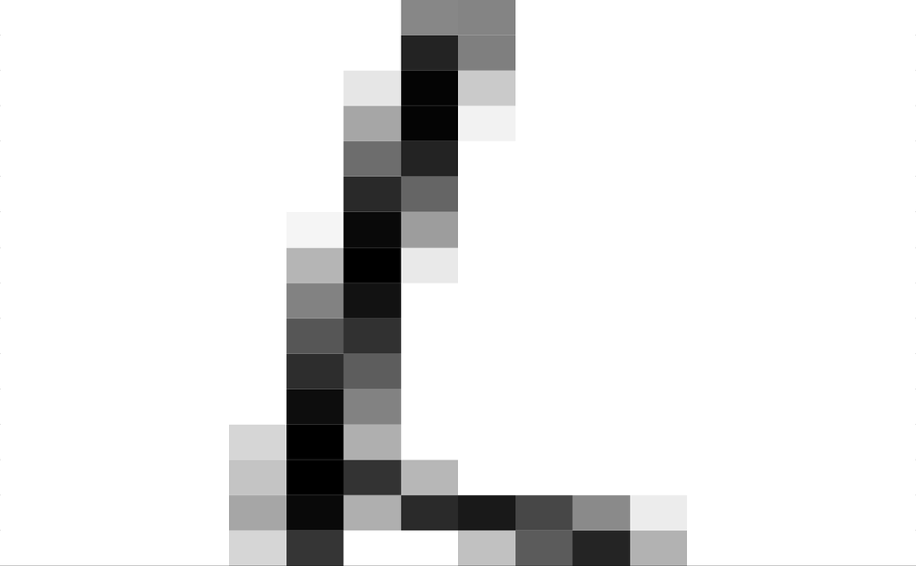

```r
one.as.five <- intersect(which(y.test.svm==5), which(dat$test[,1]==1))
conv.image(dat$test[one.as.five[1], -1])
for (i in 1:length(one.as.five)) {
  pdf(paste0('one.as.five', i, '.pdf'))
  conv.image(dat$test[one.as.five[i], -1])
  dev.off()
}
```

Three’s that are misclassified as five’s:

[figure not shown]

```r
three.as.five <- intersect(which(y.test.svm==5), which(dat$test[,1]==3))
conv.image(dat$test[three.as.five[1], -1])
for (i in 1:length(three.as.five)) {
  pdf(paste0('three.as.five', i, '.pdf'))
  conv.image(dat$test[three.as.five[i], -1])
  dev.off()
}
```

Five’s that are misclassified as three’s:

[figure not shown]

```r
five.as.three <- intersect(which(y.test.svm==3), which(dat$test[,1]==5))
conv.image(dat$test[five.as.three[1], -1])
for (i in 1:length(five.as.three)) {
  pdf(paste0('five.as.three', i, '.pdf'))
  conv.image(dat$test[five.as.three[i], -1])
  dev.off()
}
```

### 4.4

#### Radial basis kernel

```r
costs <- 10^(-2:2)
gammas <- 10^(-5:5)
for (cost in costs) {
  for (gamma in gammas) {
    predictor <- function(train, test) {
      data.svm <- svm(V1 ~ ., data=train, cost=cost, gamma=gamma, scale=F)
      predict(data.svm, test)
    }
    cv.error <- cv.5fold(dat$train, predictor)
    cat("cost =", cost, ", gamma =", gamma, ", cv error =", cv.error, "\n")
  }
}
```

```
cost = 0.01 , gamma = 1e-05 , cv error = 0.547096
cost = 0.01 , gamma = 1e-04 , cv error = 0.547096
cost = 0.01 , gamma = 0.001 , cv error = 0.2987859
cost = 0.01 , gamma = 0.01 , cv error = 0.2528176
cost = 0.01 , gamma = 0.1 , cv error = 0.547096
cost = 0.01 , gamma = 1 , cv error = 0.547096
cost = 0.01 , gamma = 10 , cv error = 0.547096
cost = 0.01 , gamma = 100 , cv error = 0.547096
cost = 0.01 , gamma = 1000 , cv error = 0.547096
cost = 0.01 , gamma = 10000 , cv error = 0.547096
cost = 0.01 , gamma = 1e+05 , cv error = 0.547096
cost = 0.1 , gamma = 1e-05 , cv error = 0.547096
cost = 0.1 , gamma = 1e-04 , cv error = 0.2654414
cost = 0.1 , gamma = 0.001 , cv error = 0.02659183
cost = 0.1 , gamma = 0.01 , cv error = 0.02118134
cost = 0.1 , gamma = 0.1 , cv error = 0.2947288
cost = 0.1 , gamma = 1 , cv error = 0.547096
cost = 0.1 , gamma = 10 , cv error = 0.547096
cost = 0.1 , gamma = 100 , cv error = 0.547096
cost = 0.1 , gamma = 1000 , cv error = 0.547096
cost = 0.1 , gamma = 10000 , cv error = 0.547096
cost = 0.1 , gamma = 1e+05 , cv error = 0.547096
cost = 1 , gamma = 1e-05 , cv error = 0.2658929
cost = 1 , gamma = 1e-04 , cv error = 0.0270433
cost = 1 , gamma = 0.001 , cv error = 0.01937954
cost = 1 , gamma = 0.01 , cv error = 0.006759807
cost = 1 , gamma = 0.1 , cv error = 0.2640829
cost = 1 , gamma = 1 , cv error = 0.547096
cost = 1 , gamma = 10 , cv error = 0.547096
cost = 1 , gamma = 100 , cv error = 0.547096
cost = 1 , gamma = 1000 , cv error = 0.547096
cost = 1 , gamma = 10000 , cv error = 0.547096
cost = 1 , gamma = 1e+05 , cv error = 0.547096
cost = 10 , gamma = 1e-05 , cv error = 0.02749476
cost = 10 , gamma = 1e-04 , cv error = 0.02208224
cost = 10 , gamma = 0.001 , cv error = 0.01487198
cost = 10 , gamma = 0.01 , cv error = 0.005857889
cost = 10 , gamma = 0.1 , cv error = 0.2564192
cost = 10 , gamma = 1 , cv error = 0.547096
cost = 10 , gamma = 10 , cv error = 0.547096
cost = 10 , gamma = 100 , cv error = 0.547096
cost = 10 , gamma = 1000 , cv error = 0.547096
cost = 10 , gamma = 10000 , cv error = 0.547096
cost = 10 , gamma = 1e+05 , cv error = 0.547096
cost = 100 , gamma = 1e-05 , cv error = 0.02208224
cost = 100 , gamma = 1e-04 , cv error = 0.02208427
cost = 100 , gamma = 0.001 , cv error = 0.01397108
cost = 100 , gamma = 0.01 , cv error = 0.005857889
cost = 100 , gamma = 0.1 , cv error = 0.2564192
cost = 100 , gamma = 1 , cv error = 0.547096
cost = 100 , gamma = 10 , cv error = 0.547096
cost = 100 , gamma = 100 , cv error = 0.547096
cost = 100 , gamma = 1000 , cv error = 0.547096
cost = 100 , gamma = 10000 , cv error = 0.547096
cost = 100 , gamma = 1e+05 , cv error = 0.547096
```

We find that `cost` = 8 and `gamma` = 0.0078125 is one combination of parameters that have the lowest CV error (0.005903646).

```r
costs <- 2^(-1:7)
gammas <- 2^(-9:-4)
for (cost in costs) {
  for (gamma in gammas) {
    predictor <- function(train, test) {
      data.svm <- svm(V1 ~ ., data=train, cost=cost, gamma=gamma, scale=F)
      predict(data.svm, test)
    }
    cv.errors <- sapply(1:10, function(i) cv.5fold(dat$train, predictor, seed=i))
    cat("cost =", cost, ", gamma =", gamma, ", cv error =", mean(cv.errors), "\n")
  }
}
```

```
cost = 0.5 , gamma = 0.001953125 , cv error = 0.01960364
cost = 0.5 , gamma = 0.00390625 , cv error = 0.01464645
cost = 0.5 , gamma = 0.0078125 , cv error = 0.01090548
cost = 0.5 , gamma = 0.015625 , cv error = 0.01167165
cost = 0.5 , gamma = 0.03125 , cv error = 0.02564222
cost = 0.5 , gamma = 0.0625 , cv error = 0.2571437
cost = 1 , gamma = 0.001953125 , cv error = 0.01523194
cost = 1 , gamma = 0.00390625 , cv error = 0.01153651
cost = 1 , gamma = 0.0078125 , cv error = 0.007841092
cost = 1 , gamma = 0.015625 , cv error = 0.008111667
cost = 1 , gamma = 0.03125 , cv error = 0.01581762
cost = 1 , gamma = 0.0625 , cv error = 0.06687562
cost = 2 , gamma = 0.001953125 , cv error = 0.01338397
cost = 2 , gamma = 0.00390625 , cv error = 0.009688752
cost = 2 , gamma = 0.0078125 , cv error = 0.006083725
cost = 2 , gamma = 0.015625 , cv error = 0.007525776
cost = 2 , gamma = 0.03125 , cv error = 0.01523183
cost = 2 , gamma = 0.0625 , cv error = 0.06241443
cost = 4 , gamma = 0.001953125 , cv error = 0.01225774
cost = 4 , gamma = 0.00390625 , cv error = 0.00788634
cost = 4 , gamma = 0.0078125 , cv error = 0.005903646
cost = 4 , gamma = 0.015625 , cv error = 0.007525776
cost = 4 , gamma = 0.03125 , cv error = 0.01523183
cost = 4 , gamma = 0.0625 , cv error = 0.06241443
cost = 8 , gamma = 0.001953125 , cv error = 0.01068045
cost = 8 , gamma = 0.00390625 , cv error = 0.007435991
cost = 8 , gamma = 0.0078125 , cv error = 0.005903646
cost = 8 , gamma = 0.015625 , cv error = 0.007525776
cost = 8 , gamma = 0.03125 , cv error = 0.01523183
cost = 8 , gamma = 0.0625 , cv error = 0.06241443
cost = 16 , gamma = 0.001953125 , cv error = 0.009824294
cost = 16 , gamma = 0.00390625 , cv error = 0.007435991
cost = 16 , gamma = 0.0078125 , cv error = 0.005903646
cost = 16 , gamma = 0.015625 , cv error = 0.007525776
cost = 16 , gamma = 0.03125 , cv error = 0.01523183
cost = 16 , gamma = 0.0625 , cv error = 0.06241443
cost = 32 , gamma = 0.001953125 , cv error = 0.009823989
cost = 32 , gamma = 0.00390625 , cv error = 0.007435991
cost = 32 , gamma = 0.0078125 , cv error = 0.005903646
cost = 32 , gamma = 0.015625 , cv error = 0.007525776
cost = 32 , gamma = 0.03125 , cv error = 0.01523183
cost = 32 , gamma = 0.0625 , cv error = 0.06241443
cost = 64 , gamma = 0.001953125 , cv error = 0.009823989
cost = 64 , gamma = 0.00390625 , cv error = 0.007435991
cost = 64 , gamma = 0.0078125 , cv error = 0.005903646
cost = 64 , gamma = 0.015625 , cv error = 0.007525776
cost = 64 , gamma = 0.03125 , cv error = 0.01523183
cost = 64 , gamma = 0.0625 , cv error = 0.06241443
cost = 128 , gamma = 0.001953125 , cv error = 0.009823989
cost = 128 , gamma = 0.00390625 , cv error = 0.007435991
cost = 128 , gamma = 0.0078125 , cv error = 0.005903646
cost = 128 , gamma = 0.015625 , cv error = 0.007525776
cost = 128 , gamma = 0.03125 , cv error = 0.01523183
cost = 128 , gamma = 0.0625 , cv error = 0.06241443
```

Check the 5-fold CV error:

```r
cv.error <- 0
for (seed in 1:20) {
  set.seed(seed)
  ind <- sample(1:nrow(dat$train))
  train.ind <- ind[c(1:as.integer(nrow(dat$train)*.8))]
  data.svm <- svm(V1 ~ ., data=dat$train[train.ind,], cost=16, gamma=0.0078125, scale=F)
  cv.error <- cv.error + mean(predict(data.svm, dat$train[-train.ind,]) != dat$train[-train.ind,1])
}
cv.error/20
```

```
[1] 0.007207207
```

#### Polynomial kernel

`cost` is set to 8 as in the above RBF kernel case:

```r
gammas <- 10^(-5:1)
coef0s <- 10^(-5:5)
degrees <- c(2, 3)
for (gamma in gammas) {
  for (coef0 in coef0s) {
    for (degree in degrees) {
      predictor <- function(train, test) {
        data.svm <- svm(V1 ~ ., data=train, kernel="polynomial",
                        cost=8, gamma=gamma, coef0=coef0, degree=degree, scale=F)
        predict(data.svm, test)
      }
      cv.error <- cv.5fold(dat$train, predictor)
      cat("gamma =", gamma, ", coef0 =", coef0, ", degree =", degree, ", cv error =", cv.error, "\n")
    }
  }
}
```

```
gamma = 1e-05 , coef0 = 1e-05 , degree = 2 , cv error = 0.547096
gamma = 1e-05 , coef0 = 1e-05 , degree = 3 , cv error = 0.547096
gamma = 1e-05 , coef0 = 1e-04 , degree = 2 , cv error = 0.547096
gamma = 1e-05 , coef0 = 1e-04 , degree = 3 , cv error = 0.547096
gamma = 1e-05 , coef0 = 0.001 , degree = 2 , cv error = 0.547096
gamma = 1e-05 , coef0 = 0.001 , degree = 3 , cv error = 0.547096
gamma = 1e-05 , coef0 = 0.01 , degree = 2 , cv error = 0.547096
gamma = 1e-05 , coef0 = 0.01 , degree = 3 , cv error = 0.547096
gamma = 1e-05 , coef0 = 0.1 , degree = 2 , cv error = 0.3258262
gamma = 1e-05 , coef0 = 0.1 , degree = 3 , cv error = 0.547096
gamma = 1e-05 , coef0 = 1 , degree = 2 , cv error = 0.02839465
gamma = 1e-05 , coef0 = 1 , degree = 3 , cv error = 0.02749476
gamma = 1e-05 , coef0 = 10 , degree = 2 , cv error = 0.02253472
gamma = 1e-05 , coef0 = 10 , degree = 3 , cv error = 0.02298619
gamma = 1e-05 , coef0 = 100 , degree = 2 , cv error = 0.02073191
gamma = 1e-05 , coef0 = 100 , degree = 3 , cv error = 0.01938259
gamma = 1e-05 , coef0 = 1000 , degree = 2 , cv error = 0.02343664
gamma = 1e-05 , coef0 = 1000 , degree = 3 , cv error = 0.02343766
gamma = 1e-05 , coef0 = 10000 , degree = 2 , cv error = 0.02163687
gamma = 1e-05 , coef0 = 10000 , degree = 3 , cv error = 0.02253371
gamma = 1e-05 , coef0 = 1e+05 , degree = 2 , cv error = 0.2032538
```

[output not shown]

```
gamma = 1e-05 , coef0 = 1e+05 , degree = 3 , cv error = 0.1883757
gamma = 1e-04 , coef0 = 1e-05 , degree = 2 , cv error = 0.2532711
gamma = 1e-04 , coef0 = 1e-05 , degree = 3 , cv error = 0.547096
gamma = 1e-04 , coef0 = 1e-04 , degree = 2 , cv error = 0.2532711
gamma = 1e-04 , coef0 = 1e-04 , degree = 3 , cv error = 0.547096
gamma = 1e-04 , coef0 = 0.001 , degree = 2 , cv error = 0.2528196
gamma = 1e-04 , coef0 = 0.001 , degree = 3 , cv error = 0.547096
gamma = 1e-04 , coef0 = 0.01 , degree = 2 , cv error = 0.2492109
gamma = 1e-04 , coef0 = 0.01 , degree = 3 , cv error = 0.547096
gamma = 1e-04 , coef0 = 0.1 , degree = 2 , cv error = 0.02659183
gamma = 1e-04 , coef0 = 0.1 , degree = 3 , cv error = 0.2483131
gamma = 1e-04 , coef0 = 1 , degree = 2 , cv error = 0.02253472
gamma = 1e-04 , coef0 = 1 , degree = 3 , cv error = 0.02118032
gamma = 1e-04 , coef0 = 10 , degree = 2 , cv error = 0.01982897
gamma = 1e-04 , coef0 = 10 , degree = 3 , cv error = 0.01983202
gamma = 1e-04 , coef0 = 100 , degree = 2 , cv error = 0.02028349
gamma = 1e-04 , coef0 = 100 , degree = 3 , cv error = 0.02073394
gamma = 1e-04 , coef0 = 1000 , degree = 2 , cv error = 0.01848067
gamma = 1e-04 , coef0 = 1000 , degree = 3 , cv error = 0.02028349
gamma = 1e-04 , coef0 = 10000 , degree = 2 , cv error = 0.0261424
gamma = 1e-04 , coef0 = 10000 , degree = 3 , cv error = 0.02749578
gamma = 1e-04 , coef0 = 1e+05 , degree = 2 , cv error = 0.02433958
gamma = 1e-04 , coef0 = 1e+05 , degree = 3 , cv error = 0.02613833
gamma = 0.001 , coef0 = 1e-05 , degree = 2 , cv error = 0.01577492
gamma = 0.001 , coef0 = 1e-05 , degree = 3 , cv error = 0.02208326
gamma = 0.001 , coef0 = 1e-04 , degree = 2 , cv error = 0.01577492
gamma = 0.001 , coef0 = 1e-04 , degree = 3 , cv error = 0.02208326
gamma = 0.001 , coef0 = 0.001 , degree = 2 , cv error = 0.01577492
gamma = 0.001 , coef0 = 0.001 , degree = 3 , cv error = 0.02208326
gamma = 0.001 , coef0 = 0.01 , degree = 2 , cv error = 0.01442153
gamma = 0.001 , coef0 = 0.01 , degree = 3 , cv error = 0.02118236
gamma = 0.001 , coef0 = 0.1 , degree = 2 , cv error = 0.01487097
gamma = 0.001 , coef0 = 0.1 , degree = 3 , cv error = 0.01712627
gamma = 0.001 , coef0 = 1 , degree = 2 , cv error = 0.01712525
gamma = 0.001 , coef0 = 1 , degree = 3 , cv error = 0.01487198
gamma = 0.001 , coef0 = 10 , degree = 2 , cv error = 0.01847965
gamma = 0.001 , coef0 = 10 , degree = 3 , cv error = 0.01893214
gamma = 0.001 , coef0 = 100 , degree = 2 , cv error = 0.02118439
gamma = 0.001 , coef0 = 100 , degree = 3 , cv error = 0.02073394
gamma = 0.001 , coef0 = 1000 , degree = 2 , cv error = 0.02118439
```

[output cut: 78 more lines]

```
gamma = 10 , coef0 = 0.01 , degree = 3 , cv error = 0.006759807
gamma = 10 , coef0 = 0.1 , degree = 2 , cv error = 0.008561609
gamma = 10 , coef0 = 0.1 , degree = 3 , cv error = 0.006759807
gamma = 10 , coef0 = 1 , degree = 2 , cv error = 0.008561609
gamma = 10 , coef0 = 1 , degree = 3 , cv error = 0.006759807
gamma = 10 , coef0 = 10 , degree = 2 , cv error = 0.008561609
gamma = 10 , coef0 = 10 , degree = 3 , cv error = 0.006759807
gamma = 10 , coef0 = 100 , degree = 2 , cv error = 0.008561609
gamma = 10 , coef0 = 100 , degree = 3 , cv error = 0.006759807
gamma = 10 , coef0 = 1000 , degree = 2 , cv error = 0.01036341
gamma = 10 , coef0 = 1000 , degree = 3 , cv error = 0.009012059
gamma = 10 , coef0 = 10000 , degree = 2 , cv error = 0.01667683
gamma = 10 , coef0 = 10000 , degree = 3 , cv error = 0.01442255
gamma = 10 , coef0 = 1e+05 , degree = 2 , cv error = 0.01893214
gamma = 10 , coef0 = 1e+05 , degree = 3 , cv error = 0.01893214
```

We find that `cost` = 8 (preset), `gamma` = 0.125, `coef0` = 0.01 and `degree` = 3 is one combination of parameters that have the lowest CV error (0.005678116).

```r
gammas <- 2^(-6:3)
coef0s <- 10^(-4:0)
degrees <- c(2, 3)
for (gamma in gammas) {
  for (coef0 in coef0s) {
    for (degree in degrees) {
      predictor <- function(train, test) {
        data.svm <- svm(V1 ~ ., data=train, kernel="polynomial",
                        cost=8, gamma=gamma, coef0=coef0, degree=degree, scale=F)
        predict(data.svm, test)
      }
      cv.errors <- sapply(1:10, function(i) cv.5fold(dat$train, predictor, seed=i))
      cat("gamma =", gamma, ", coef0 =", coef0, ", degree =", degree, ", cv error =", mean(cv.errors), "\n")
    }
  }
}
```

```
gamma = 0.015625 , coef0 = 1e-04 , degree = 2 , cv error = 0.00757133
gamma = 0.015625 , coef0 = 1e-04 , degree = 3 , cv error = 0.005678116
gamma = 0.015625 , coef0 = 0.001 , degree = 2 , cv error = 0.00757133
gamma = 0.015625 , coef0 = 0.001 , degree = 3 , cv error = 0.005678116
gamma = 0.015625 , coef0 = 0.01 , degree = 2 , cv error = 0.00757133
gamma = 0.015625 , coef0 = 0.01 , degree = 3 , cv error = 0.005678116
gamma = 0.015625 , coef0 = 0.1 , degree = 2 , cv error = 0.007706465
gamma = 0.015625 , coef0 = 0.1 , degree = 3 , cv error = 0.005723161
gamma = 0.015625 , coef0 = 1 , degree = 2 , cv error = 0.008968133
gamma = 0.015625 , coef0 = 1 , degree = 3 , cv error = 0.006669514
gamma = 0.03125 , coef0 = 1e-04 , degree = 2 , cv error = 0.00757133
gamma = 0.03125 , coef0 = 1e-04 , degree = 3 , cv error = 0.005678116
gamma = 0.03125 , coef0 = 0.001 , degree = 2 , cv error = 0.00757133
gamma = 0.03125 , coef0 = 0.001 , degree = 3 , cv error = 0.005678116
gamma = 0.03125 , coef0 = 0.01 , degree = 2 , cv error = 0.00757133
gamma = 0.03125 , coef0 = 0.01 , degree = 3 , cv error = 0.005678116
gamma = 0.03125 , coef0 = 0.1 , degree = 2 , cv error = 0.007706465
gamma = 0.03125 , coef0 = 0.1 , degree = 3 , cv error = 0.005723161
gamma = 0.03125 , coef0 = 1 , degree = 2 , cv error = 0.008202062
gamma = 0.03125 , coef0 = 1 , degree = 3 , cv error = 0.006083725
gamma = 0.0625 , coef0 = 1e-04 , degree = 2 , cv error = 0.00757133
gamma = 0.0625 , coef0 = 1e-04 , degree = 3 , cv error = 0.005678116
gamma = 0.0625 , coef0 = 0.001 , degree = 2 , cv error = 0.00757133
gamma = 0.0625 , coef0 = 0.001 , degree = 3 , cv error = 0.005678116
gamma = 0.0625 , coef0 = 0.01 , degree = 2 , cv error = 0.00757133
gamma = 0.0625 , coef0 = 0.01 , degree = 3 , cv error = 0.005678116
gamma = 0.0625 , coef0 = 0.1 , degree = 2 , cv error = 0.00766142
gamma = 0.0625 , coef0 = 0.1 , degree = 3 , cv error = 0.005678116
gamma = 0.0625 , coef0 = 1 , degree = 2 , cv error = 0.0078416
gamma = 0.0625 , coef0 = 1 , degree = 3 , cv error = 0.005858398
gamma = 0.125 , coef0 = 1e-04 , degree = 2 , cv error = 0.00757133
gamma = 0.125 , coef0 = 1e-04 , degree = 3 , cv error = 0.005678116
gamma = 0.125 , coef0 = 0.001 , degree = 2 , cv error = 0.00757133
gamma = 0.125 , coef0 = 0.001 , degree = 3 , cv error = 0.005678116
gamma = 0.125 , coef0 = 0.01 , degree = 2 , cv error = 0.00757133
gamma = 0.125 , coef0 = 0.01 , degree = 3 , cv error = 0.005678116
gamma = 0.125 , coef0 = 0.1 , degree = 2 , cv error = 0.00757133
gamma = 0.125 , coef0 = 0.1 , degree = 3 , cv error = 0.005678116
gamma = 0.125 , coef0 = 1 , degree = 2 , cv error = 0.007706465
gamma = 0.125 , coef0 = 1 , degree = 3 , cv error = 0.005678116
```

[output cut: 45 more lines]

```
gamma = 4 , coef0 = 0.01 , degree = 3 , cv error = 0.005678116
gamma = 4 , coef0 = 0.1 , degree = 2 , cv error = 0.00757133
gamma = 4 , coef0 = 0.1 , degree = 3 , cv error = 0.005678116
gamma = 4 , coef0 = 1 , degree = 2 , cv error = 0.00757133
gamma = 4 , coef0 = 1 , degree = 3 , cv error = 0.005678116
gamma = 8 , coef0 = 1e-04 , degree = 2 , cv error = 0.00757133
gamma = 8 , coef0 = 1e-04 , degree = 3 , cv error = 0.005678116
gamma = 8 , coef0 = 0.001 , degree = 2 , cv error = 0.00757133
gamma = 8 , coef0 = 0.001 , degree = 3 , cv error = 0.005678116
gamma = 8 , coef0 = 0.01 , degree = 2 , cv error = 0.00757133
gamma = 8 , coef0 = 0.01 , degree = 3 , cv error = 0.005678116
gamma = 8 , coef0 = 0.1 , degree = 2 , cv error = 0.00757133
gamma = 8 , coef0 = 0.1 , degree = 3 , cv error = 0.005678116
gamma = 8 , coef0 = 1 , degree = 2 , cv error = 0.00757133
gamma = 8 , coef0 = 1 , degree = 3 , cv error = 0.005678116
```

Check the 5-fold CV error:

```r
set.seed(10)
ind <- sample(1:nrow(dat$train))
train.ind <- ind[c(1:as.integer(nrow(dat$train)*.8))]
data.svm <- svm(V1 ~ ., data=dat$train[train.ind,], kernel="polynomial",
                cost=8, gamma=0.125, coef0=0.01, degree=3, scale=F)
mean(predict(data.svm, dat$train[-train.ind,]) != dat$train[-train.ind,1])
```

```
[1] 0.004504505
```

## Problem 5

### 5.1

Generate a dataset with 500 samples:

```r
set.seed(10)
x1 <- runif(500) - 0.5
x2 <- runif(500) - 0.5
y <- ifelse(x1^2 - x2^2 > 0, 1, 0)
dat <- data.frame(x1, x2, y)
dat$y <- as.factor(dat$y)
```

Plot the sample points:

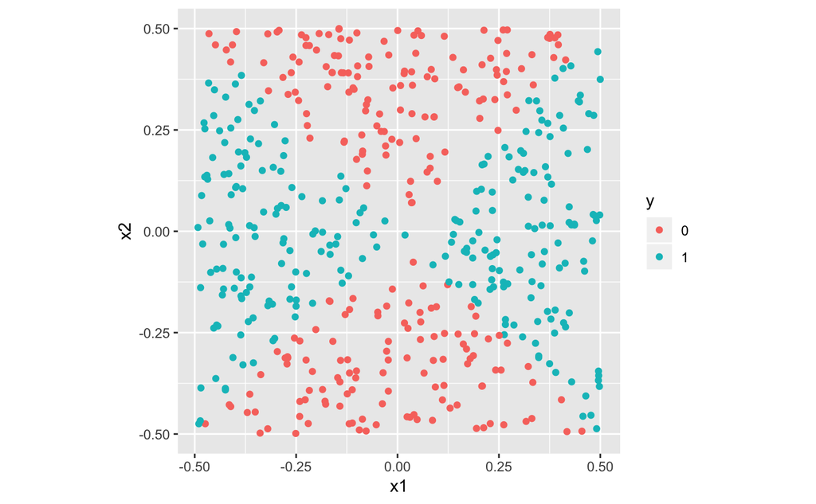

```r
ggplot(dat, aes(x=x1, y=x2, color=y)) + geom_point() + coord_fixed()
```

### 5.2

Train the data with four classifiers:

#### Linear SVM

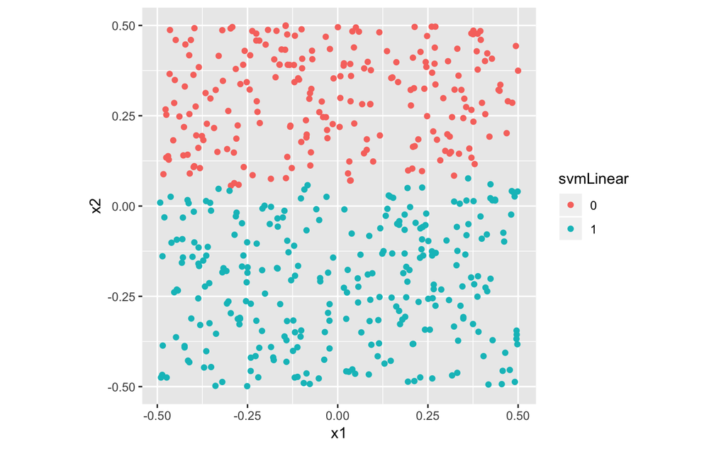

```r
dat.svmLinear <- svm(y ~ x1+x2, data=dat, kernel="linear")
dat$svmLinear <- predict(dat.svmLinear, dat)
ggplot(dat, aes(x=x1, y=x2, color=svmLinear)) + geom_point() + coord_fixed()
```

#### Nonlinear SVM

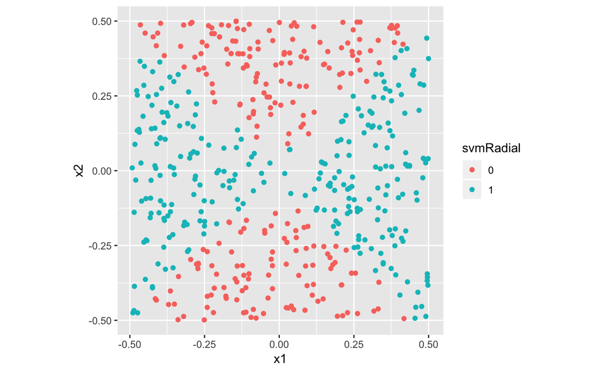

```r
dat.svmRadial <- svm(y ~ x1+x2, data=dat)
dat$svmRadial <- predict(dat.svmRadial, dat)
ggplot(dat, aes(x=x1, y=x2, color=svmRadial)) + geom_point() + coord_fixed()
```

#### LDA using `x1` and `x2`

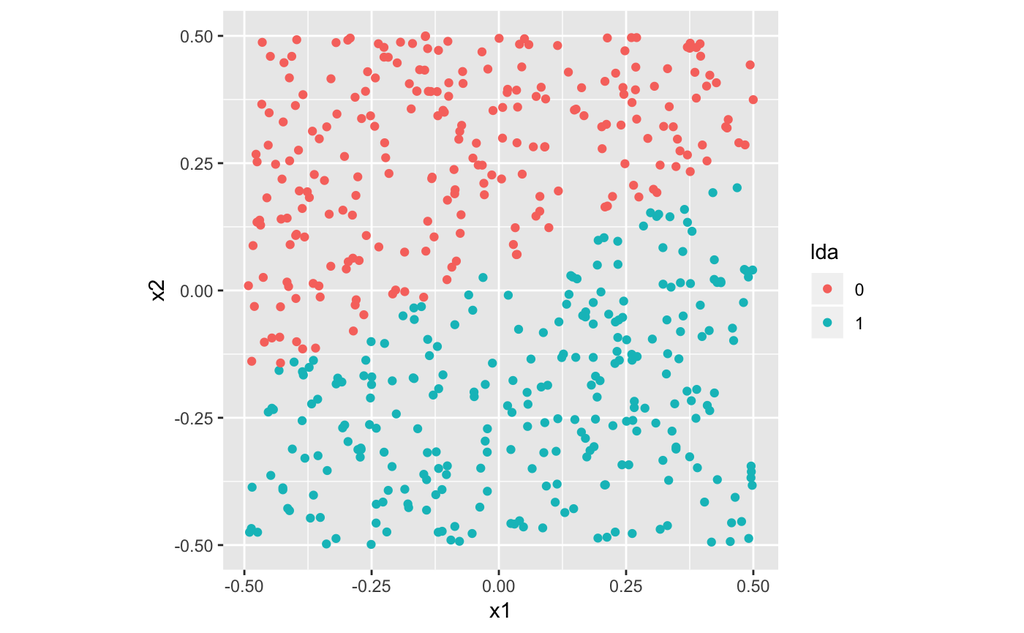

```r
library(MASS)
dat.lda <- lda(y ~ x1+x2, data=dat)
dat$lda <- predict(dat.lda, dat)$class
ggplot(dat, aes(x=x1, y=x2, color=lda)) + geom_point() + coord_fixed()
```

#### LDA using `x1`, `x2` and their squares

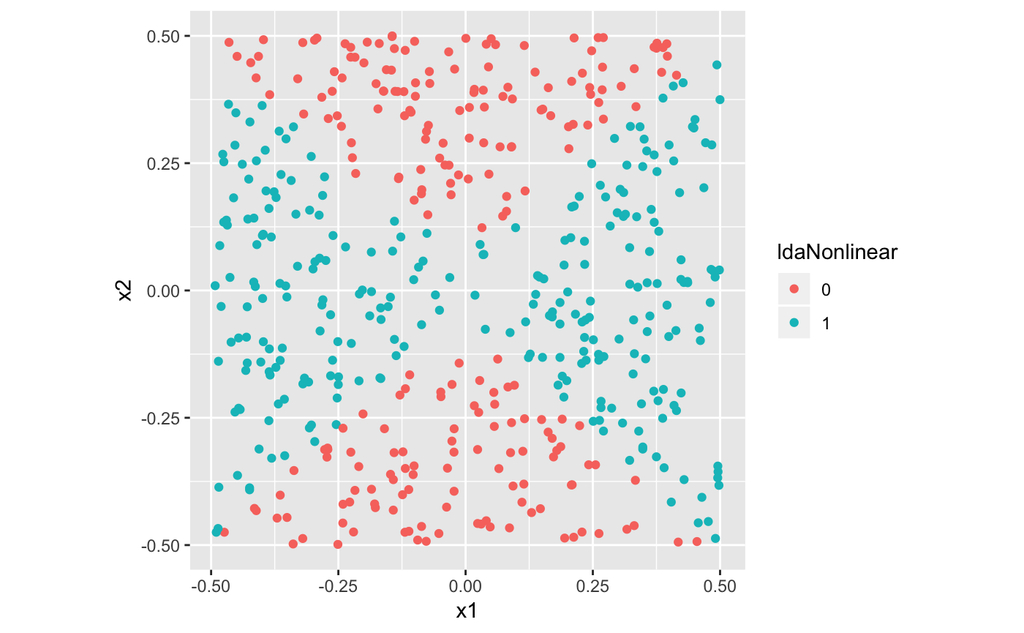

```r
dat$x1sq <- dat$x1^2
dat$x2sq <- dat$x2^2
dat.ldaNonlinear <- lda(y ~ x1+x2+x1sq+x2sq, data=dat)
dat$ldaNonlinear <- predict(dat.ldaNonlinear, dat)$class
ggplot(dat, aes(x=x1, y=x2, color=ldaNonlinear)) + geom_point() + coord_fixed()
```

The decision boundary is nonlinear, so only SVM with nonlinear kernels and LDA with nonlinear transformations of freatures can accurately predict it.